# Hypothesis Testing, Step by Step

Lessons 23–24 — Two Groups and One Group

Lt Col Cho

# Part 1

The **four steps** of a hypothesis test

What a test is · Steps 0–4 · What a p-value means

## From confidence intervals to tests

**Confidence interval**

Start with the **data**

→ a range of **plausible values** for the parameter

**Hypothesis test**

Start with a **claim** about the parameter

→ is our data **surprising** if the claim is true?

Claim → What would we expect? → Compare → Decide

## Is it just chance?

**Samples vary.** Even if a claim is exactly true, our sample won’t match it exactly.

When our sample **differs** from the claim, there are two explanations:

**Chance** ($H_0$)

The claim is true. We just got an unusual sample.

**Something real** ($H_A$)

The claim is wrong. The difference reflects the population.

A hypothesis test asks: **how surprising is our sample if only chance is at work?**

## Innocent until proven guilty

|  | Courtroom | Hypothesis test |
| --- | --- | --- |
| Assume | Defendant is **innocent** | $H_0$ is **true** |
| Want to show | **Guilty** | $H_A$ |
| Evidence | Testimony, exhibits | **Data** |
| Bar | “Beyond reasonable doubt” | $\alpha$ |
| Verdicts | **Guilty** / **Not guilty** | **Reject $H_0$** / **Fail to reject $H_0$** |

“Not guilty” ≠ “innocent”

## Step 0 · Set the bar

0 · Set α1 · Hypotheses2 · Test statistic3A · Null world3B · p-value4 · Conclusion

**Discernibility level $\alpha$** (also called the **significance level**): how rare a result must be before we reject $H_0$.

$\alpha = 0.05$

- Set it **before** looking at the data
- Not given? Use 0.05

## Step 1 · State the hypotheses

0 · Set α1 · Hypotheses2 · Test statistic3A · Null world3B · p-value4 · Conclusion

- $H_0$ (**null**): no difference / no effect / the status quo. *“The null is dull.”*
- $H_A$ (**alternative**): what we want to show.

|  | One group | Two groups |
| --- | --- | --- |
| $H_0$ | parameter = claimed value | difference = 0 |
| $H_A$ | parameter $<$, $>$, or $\ne$ claimed value | difference $<$, $>$, or $\ne$ 0 |
| Example | $H_0: \mu = 98.6$ | $H_0: p_1 - p_2 = 0$ |

| Wording in the question | $H_A$ uses | Test |
| --- | --- | --- |
| “different,” “changed” | $\ne$ | **two-sided** |
| “greater,” “increased,” “more” | $>$ | one-sided |
| “less,” “decreased,” “fewer” | $<$ | one-sided |

Hypotheses are about **parameters** (the truth), never the sample.

## Step 2 · Compute the test statistic

0 · Set α1 · Hypotheses2 · Test statistic3A · Null world3B · p-value4 · Conclusion

**Test statistic**: the sample version of the quantity in $H_0$, computed from our data.

| Parameter in $H_0$ | Test statistic |
| --- | --- |
| Proportion $p$ | Sample proportion $\hat{p}$ |
| Mean $\mu$ | Sample mean $\bar{x}$ |
| Median | Sample median |
| Difference $p_1 - p_2$ | $\hat{p}_1 - \hat{p}_2$ |
| Difference $\mu_1 - \mu_2$ | $\bar{x}_1 - \bar{x}_2$ |

Categorical (yes/no) response → **proportions** · Numerical → **means** or **medians**

## Step 3A · Build the null world

0 · Set α1 · Hypotheses2 · Test statistic3A · Null world3B · p-value4 · Conclusion

**Assume** $H_0$ is true

→

**Simulate** a new sample from that world (same $n$)

→

**Compute** the test statistic

→

**Repeat** 1000×

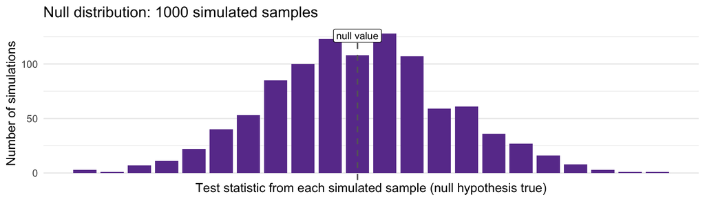

**Null distribution** = what chance alone produces if $H_0$ is true. Centered at the **null value**.

## Step 3B · Compute the p-value

0 · Set α1 · Hypotheses2 · Test statistic3A · Null world3B · p-value4 · Conclusion

**p-value**: the probability of a result **as or more extreme** than ours, **assuming $H_0$ is true**.

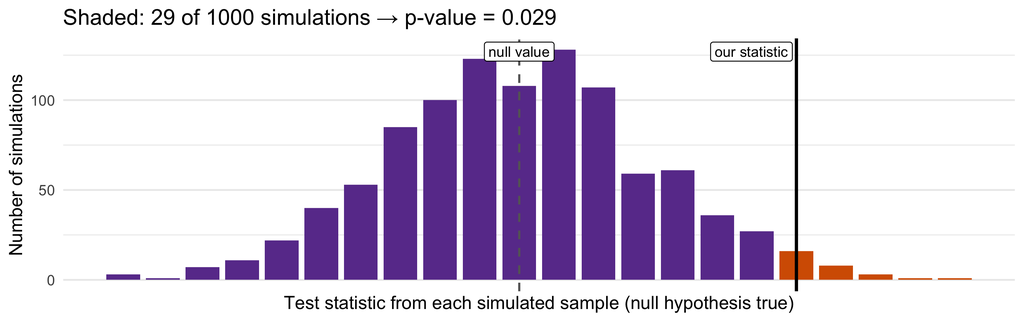

p-value = $P(\text{as or more extreme} \mid H_0 \text{ true})$ = $\dfrac{\text{shaded simulations}}{\text{all simulations}}$

## Which way do we shade?

0 · Set α1 · Hypotheses2 · Test statistic3A · Null world3B · p-value4 · Conclusion

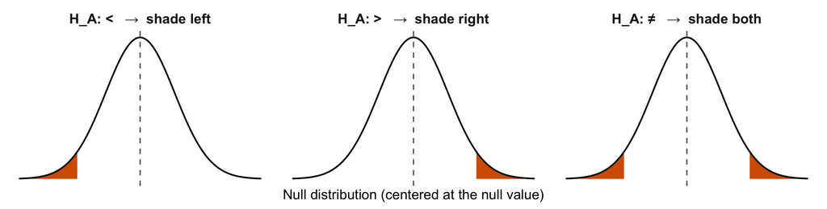

| $H_A$ | $<$ | $>$ | $\ne$ |
| --- | --- | --- | --- |
| `infer` `direction =` | `"less"` | `"greater"` | `"two-sided"` |

## Step 4 · Draw a conclusion

0 · Set α1 · Hypotheses2 · Test statistic3A · Null world3B · p-value4 · Conclusion

| If… | Decision |
| --- | --- |
| p-value $< \alpha$ | **Reject $H_0$**: statistically **discernible** evidence against $H_0$ |
| p-value $\ge \alpha$ | **Fail to reject $H_0$**: not enough evidence |

Then say it **in context**:

- About the **parameter** (the truth), not the sample
- Include the **direction** for a one-sided test

$\triangle$ **Never** “accept $H_0$”

## What a p-value is **not**

| $\triangle$ Wrong | Right |
| --- | --- |
| “p = 0.03, so there’s a 3% chance $H_0$ is true.” | p-value **assumes** $H_0$ is true |
| “p is large, so $H_0$ is true.” | Fail to reject ≠ accept |
| “p is small, so the effect is big.” | Discernible ≠ important |
| “The **sample** proportions differ.” | Conclusions are about the **parameters** |

## Recap: the four steps

| Step | Question |
| --- | --- |
| **0 · Set α** | How unusual is unusual enough? |
| **1 · Hypotheses** | What claim do we assume ($H_0$)? What do we want to show ($H_A$)? |
| **2 · Test statistic** | What did our sample show? |
| **3A · Null world** | If $H_0$ were true, what would we see? |
| **3B · p-value** | How much of the null world is as or more extreme than our sample? |
| **4 · Conclusion** | Reject or fail to reject $H_0$, **in context** |

# Part 2

Testing a **difference** between two groups

Difference in proportions · Difference in means · Difference in medians

## Three research questions: two groups

|  | **Proportions** | **Means** | **Medians** |
| --- | --- | --- | --- |
| **Question** | Does a new treatment make migraine patients pain-free more often? | Does mean heart rate differ by sex? | Are Victorian possums’ tails shorter? |
| **Response** | `pain_free` (yes/no) | `hr` (beats/min) | `tail_l` (cm) |
| **Explanatory** | `group` (treatment/control) | `sex` (male/female) | `pop` (Vic/other) |

Same four steps every time.

# Proportions — Migraine treatment

## The data

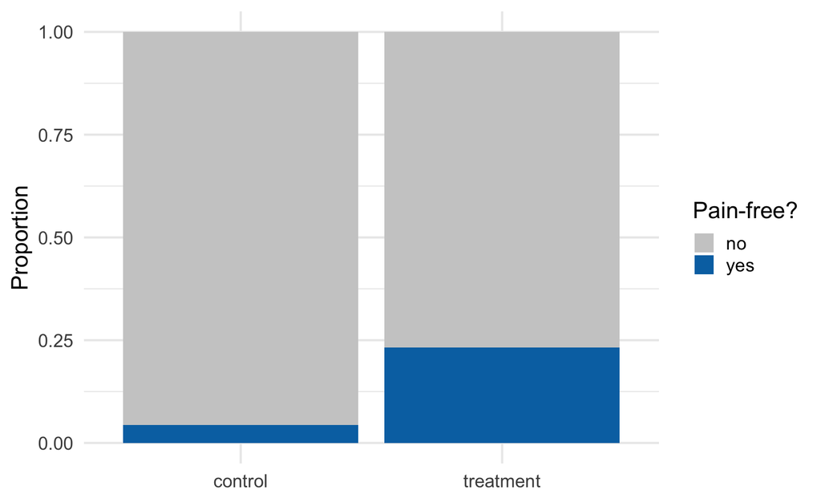

| Group | Not pain-free | Pain-free | Total |
| --- | --- | --- | --- |
| control | 44 | 2 | 46 |
| treatment | 33 | 10 | 43 |

## Step 0

0 · Set α1 · Hypotheses2 · Test statistic3A · Null world3B · p-value4 · Conclusion

$\alpha = 0.05$

Set **before** looking at the results.

## Step 1

0 · Set α1 · Hypotheses2 · Test statistic3A · Null world3B · p-value4 · Conclusion

$H_0: p_{treatment} - p_{control} = 0$

$H_A: p_{treatment} - p_{control} > 0$

- $p$ = **true** proportion of pain-free patients
- **One-sided** ( > ): only “treatment is better” counts as evidence

## Step 2

0 · Set α1 · Hypotheses2 · Test statistic3A · Null world3B · p-value4 · Conclusion

```r
obs_prop <- migraine_data %>%
  specify(response = pain_free, explanatory = group, success = "yes") %>%
  calculate(stat = "diff in props", order = c("treatment", "control")) %>%
  pull(stat)
```

$\hat{p}_{treatment} - \hat{p}_{control} = 0.233 - 0.043 = \mathbf{0.189}$

## Step 3A — one shuffle

0 · Set α1 · Hypotheses2 · Test statistic3A · Null world3B · p-value4 · Conclusion

If $H_0$ is true, the group label doesn’t matter → **shuffle the labels**.

| Pain-free? | Real group | Shuffled group |
| --- | --- | --- |
| yes | treatment | treatment |
| yes | treatment | control |
| yes | treatment | treatment |
| yes | treatment | control |
| yes | control | control |
| yes | control | control |
| no | control | treatment |
| no | control | treatment |

One shuffle → one difference:

**0.009**

## Step 3A — repeat 1000 times

0 · Set α1 · Hypotheses2 · Test statistic3A · Null world3B · p-value4 · Conclusion

```r
null_prop <- migraine_data %>%
  specify(response = pain_free,
          explanatory = group,
          success = "yes") %>%
  hypothesize(null = "independence") %>%
  generate(reps = 1000, type = "permute") %>%
  calculate(stat = "diff in props",
            order = c("treatment", "control"))
```

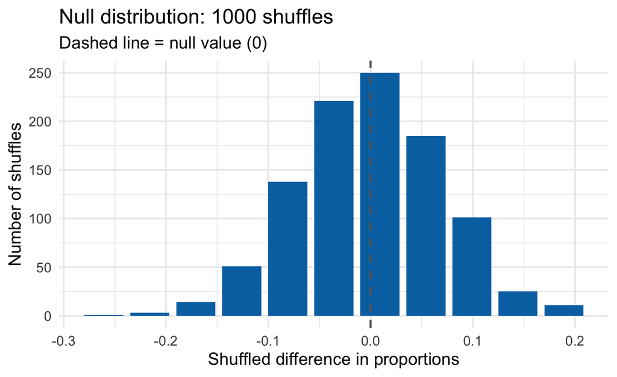

## Step 3B

0 · Set α1 · Hypotheses2 · Test statistic3A · Null world3B · p-value4 · Conclusion

$H_A$: $>$ → shade **right** (`direction = "greater"`)

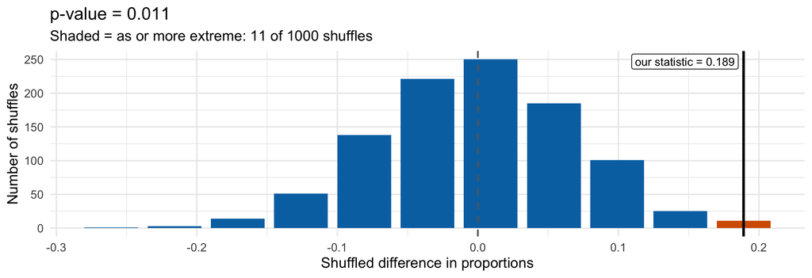

```r
null_prop %>% get_p_value(obs_stat = obs_prop, direction = "greater")
```

## Step 4

0 · Set α1 · Hypotheses2 · Test statistic3A · Null world3B · p-value4 · Conclusion

p-value = 0.011 < α = 0.05

Reject H₀

There is **sufficient evidence** that the **true** proportion of pain-free patients is **higher** with the new treatment.

# Means — Heart rate by sex

## The data

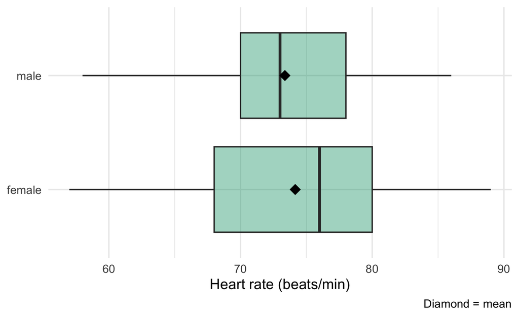

| Sex | n | Mean heart rate |
| --- | --- | --- |
| female | 65 | 74.15 |
| male | 65 | 73.37 |

## Step 0

0 · Set α1 · Hypotheses2 · Test statistic3A · Null world3B · p-value4 · Conclusion

$\alpha = 0.05$

## Step 1

0 · Set α1 · Hypotheses2 · Test statistic3A · Null world3B · p-value4 · Conclusion

$H_0: \mu_{male} - \mu_{female} = 0$

$H_A: \mu_{male} - \mu_{female} \ne 0$

- $\mu$ = **true** mean heart rate
- **Two-sided** ( $\ne$ ): a difference in **either** direction counts

## Step 2

0 · Set α1 · Hypotheses2 · Test statistic3A · Null world3B · p-value4 · Conclusion

```r
obs_mean <- hr_data %>%
  specify(response = hr, explanatory = sex) %>%
  calculate(stat = "diff in means", order = c("male", "female")) %>%
  pull(stat)
```

$\bar{x}_{male} - \bar{x}_{female} = 73.37 - 74.15 = \mathbf{-0.785}$

## Step 3A

0 · Set α1 · Hypotheses2 · Test statistic3A · Null world3B · p-value4 · Conclusion

Shuffle the **sex** labels across the 130 heart rates.

```r
null_mean <- hr_data %>%
  specify(response = hr,
          explanatory = sex) %>%
  hypothesize(null = "independence") %>%
  generate(reps = 1000, type = "permute") %>%
  calculate(stat = "diff in means",
            order = c("male", "female"))
```

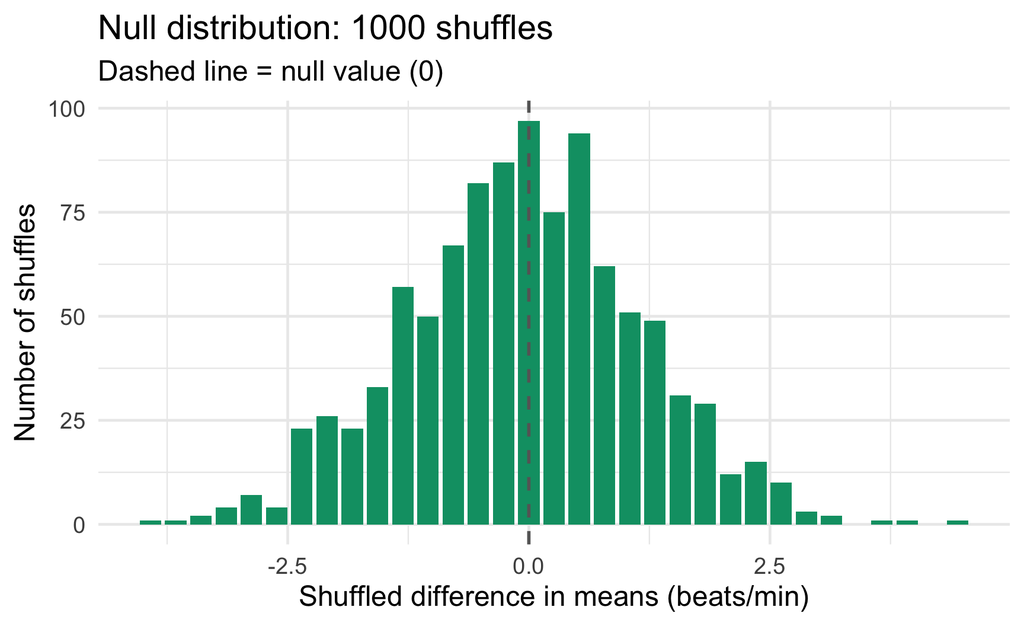

## Step 3B

0 · Set α1 · Hypotheses2 · Test statistic3A · Null world3B · p-value4 · Conclusion

$H_A$: $\ne$ → shade **both tails** (`direction = "two-sided"`)

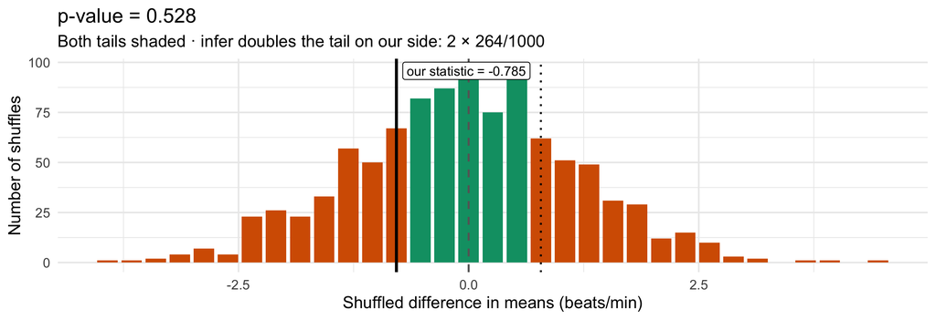

```r
null_mean %>% get_p_value(obs_stat = obs_mean, direction = "two-sided")
```

## Step 4

0 · Set α1 · Hypotheses2 · Test statistic3A · Null world3B · p-value4 · Conclusion

p-value = 0.528 ≥ α = 0.05

Fail to reject H₀

There is **not enough evidence** that the **true** mean heart rate differs between males and females.

$\triangle$ **Not** “the means are equal.” Never accept $H_0$.

# Medians — Possum tail length

## The data

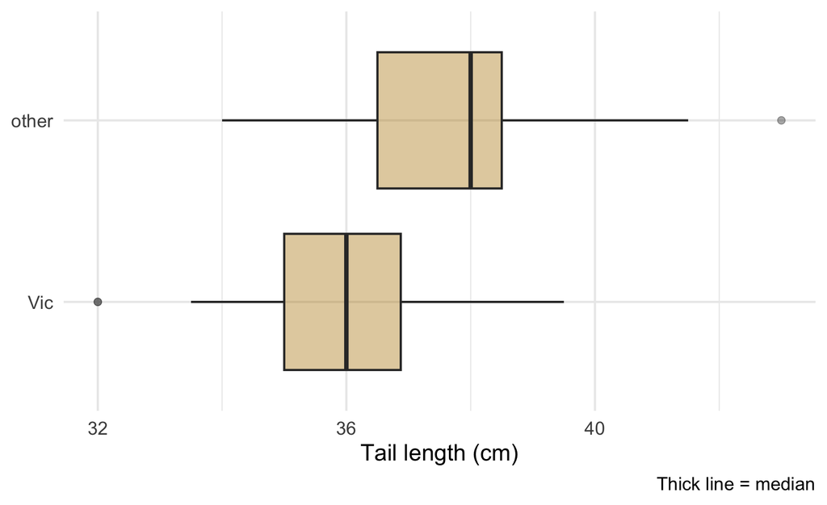

| Population | n | Median tail length (cm) |
| --- | --- | --- |
| Vic | 46 | 36 |
| other | 58 | 38 |

## Step 0

0 · Set α1 · Hypotheses2 · Test statistic3A · Null world3B · p-value4 · Conclusion

$\alpha = 0.05$

## Step 1

0 · Set α1 · Hypotheses2 · Test statistic3A · Null world3B · p-value4 · Conclusion

$H_0$: median$_{Vic}$ − median$_{other}$ = 0

$H_A$: median$_{Vic}$ − median$_{other}$ < 0

- **True** median tail lengths (write “median” in words)
- **One-sided** ( < ): only “Victorian tails are shorter” counts

## Step 2

0 · Set α1 · Hypotheses2 · Test statistic3A · Null world3B · p-value4 · Conclusion

```r
obs_median <- possum_data %>%
  specify(response = tail_l, explanatory = pop) %>%
  calculate(stat = "diff in medians", order = c("Vic", "other")) %>%
  pull(stat)
```

median$_{Vic}$ − median$_{other}$ = 36 − 38 = **-2** cm

## Step 3A

0 · Set α1 · Hypotheses2 · Test statistic3A · Null world3B · p-value4 · Conclusion

Shuffle the **population** labels across the 104 tail lengths.

```r
null_median <- possum_data %>%
  specify(response = tail_l,
          explanatory = pop) %>%
  hypothesize(null = "independence") %>%
  generate(reps = 1000, type = "permute") %>%
  calculate(stat = "diff in medians",
            order = c("Vic", "other"))
```

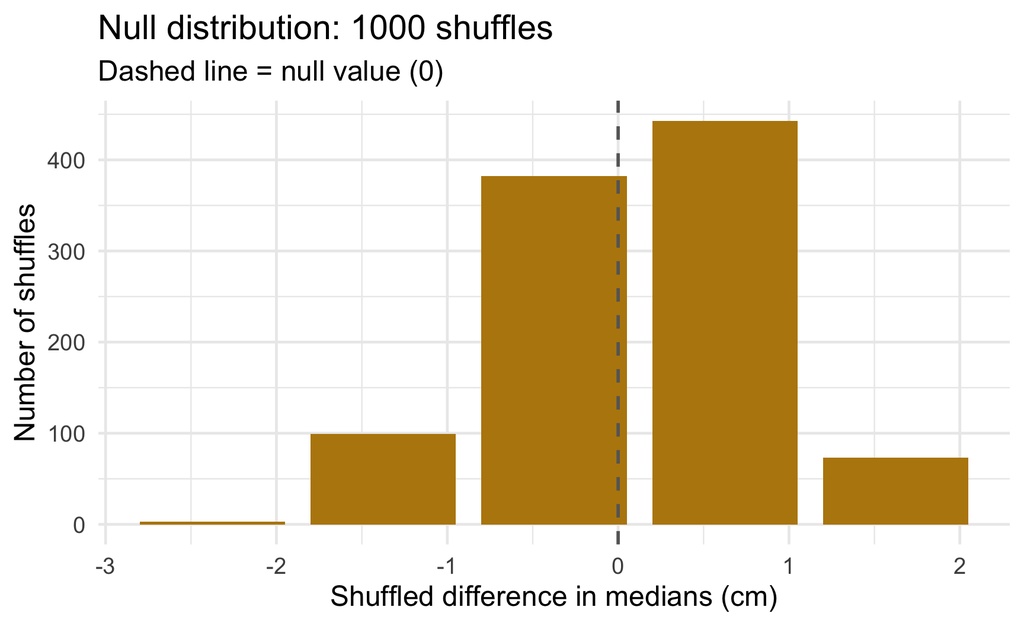

## Step 3B

0 · Set α1 · Hypotheses2 · Test statistic3A · Null world3B · p-value4 · Conclusion

$H_A$: $<$ → shade **left** (`direction = "less"`)

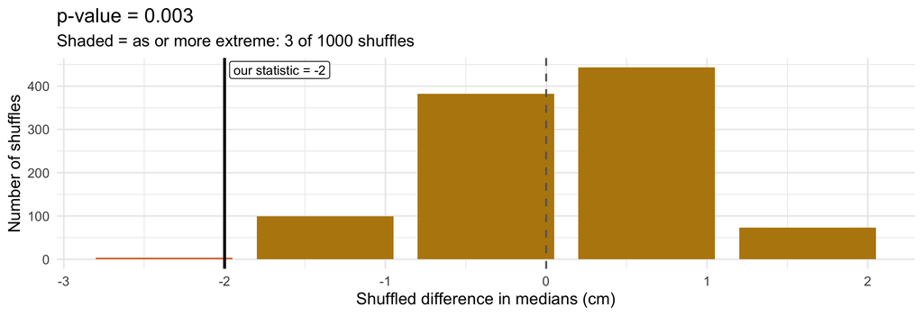

```r
null_median %>% get_p_value(obs_stat = obs_median, direction = "less")
```

## Step 4

0 · Set α1 · Hypotheses2 · Test statistic3A · Null world3B · p-value4 · Conclusion

p-value = 0.003 < α = 0.05

Reject H₀

There is **sufficient evidence** that the **true** median tail length is **shorter** for Victorian possums.

## Summary of Difference in Parameter Tests

| Step | **Proportions** | **Means** | **Medians** |
| --- | --- | --- | --- |
| **0** α | 0.05 | 0.05 | 0.05 |
| **1** $H_A$ | $p_{trt} - p_{ctrl} > 0$ | $\mu_{m} - \mu_{f} \ne 0$ | median$_{Vic}$ − median$_{other}$ < 0 |
| **2** `stat =` | `"diff in props"` | `"diff in means"` | `"diff in medians"` |
| **2** value | 0.189 | -0.785 | -2 |
| **3A** null | shuffle labels | shuffle labels | shuffle labels |
| **3B** `direction =` | `"greater"` | `"two-sided"` | `"less"` |
| **3B** p-value | 0.011 | 0.528 | 0.003 |
| **4** decision | Reject | Fail to reject | Reject |

# Part 3

Testing a **single parameter** (one group)

One proportion · One mean · One median

## Three research questions: one group

|  | **One proportion** | **One mean** | **One median** |
| --- | --- | --- | --- |
| **Question** | Is the proportion of blue M&Ms different from 25%? | Has mean body temperature decreased from 98.6 °F? | Is the median body temperature different from 98.6 °F? |
| **Variable** | `blue` (yes/no) | `temp` (°F) | `temp` (°F) |
| **Claimed value** | $p_0 = 0.25$ | $\mu_0 = 98.6$ | median$_0$ = 98.6 |

One variable, one claimed value. **Same four steps.**

## What’s different with one group?

**Two groups (Part 2)**

- $H_0$: the difference is **0**
- Null world: **shuffle** the group labels
- Null distribution centered at **0**

**One group (Part 3)**

- $H_0$: the parameter **equals a claimed value**
- Null world: **no labels to shuffle**
  - Proportion → **draw** from the claimed world
  - Mean, median → **shift** our sample, then **bootstrap**
- Null distribution centered at the **claimed value**

# One proportion — Blue M&Ms

## The data

A bag of **30** M&Ms. The New Jersey plant claims **25%** are blue.

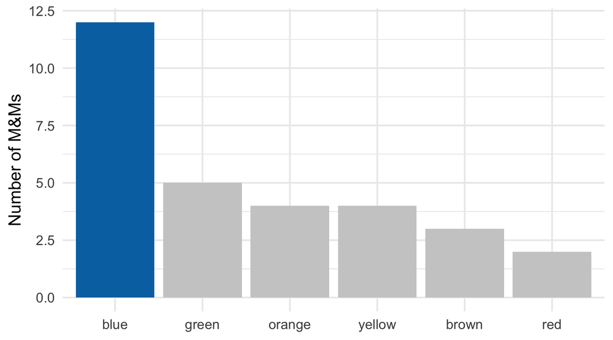

| Blue | Not blue | Total |
| --- | --- | --- |
| 12 | 18 | 30 |

## Step 0

0 · Set α1 · Hypotheses2 · Test statistic3A · Null world3B · p-value4 · Conclusion

$\alpha = 0.05$

## Step 1

0 · Set α1 · Hypotheses2 · Test statistic3A · Null world3B · p-value4 · Conclusion

$H_0: p = 0.25$

$H_A: p \ne 0.25$

- $p$ = **true** proportion of blue M&Ms
- **Two-sided** ( $\ne$ ): “different from” counts in **either** direction

## Step 2

0 · Set α1 · Hypotheses2 · Test statistic3A · Null world3B · p-value4 · Conclusion

```r
obs_mms <- mms_sample %>%
  specify(response = blue, success = "yes") %>%
  calculate(stat = "prop") %>%
  pull(stat)
```

$\hat{p} = \frac{12}{30} = \mathbf{0.4}$

`specify()` has **only a response**: one variable, no groups.

## Step 3A — one draw

0 · Set α1 · Hypotheses2 · Test statistic3A · Null world3B · p-value4 · Conclusion

**No groups → nothing to shuffle.** But $H_0$ describes the whole world: **exactly 25% blue**.

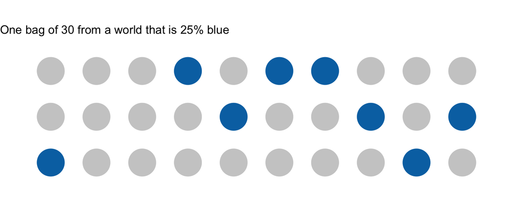

- Imagine a **giant bag** that is exactly 25% blue
- **Draw 30**, compute $\hat{p}$

One draw → one $\hat{p}$:

**8/30 = 0.267**

## Step 3A — repeat 1000 times

0 · Set α1 · Hypotheses2 · Test statistic3A · Null world3B · p-value4 · Conclusion

```r
null_mms <- mms_sample %>%
  specify(response = blue,
          success = "yes") %>%
  hypothesize(null = "point",
              p = 0.25) %>%
  generate(reps = 1000,
           type = "draw") %>%
  calculate(stat = "prop")
```

`type = "draw"`: simulate from the claimed world.

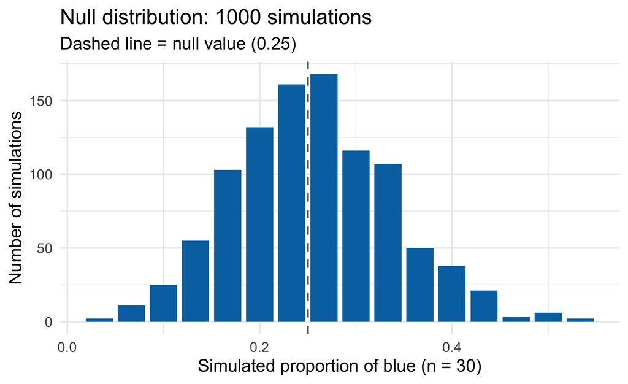

## Step 3B

0 · Set α1 · Hypotheses2 · Test statistic3A · Null world3B · p-value4 · Conclusion

$H_A$: $\ne$ → shade **both tails** (`direction = "two-sided"`)

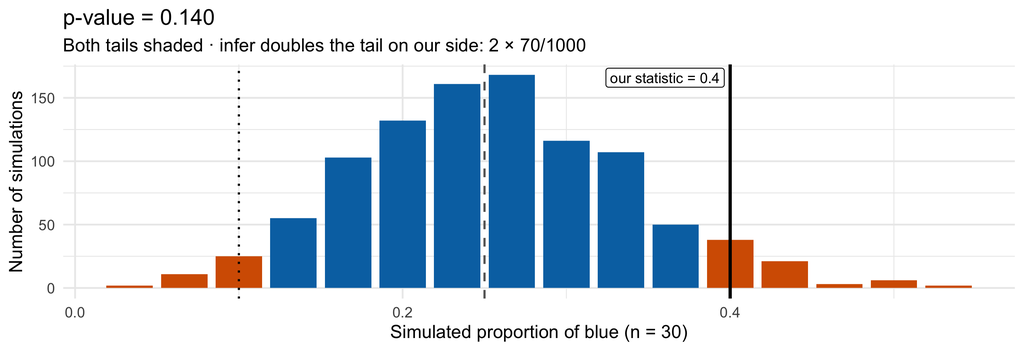

```r
null_mms %>% get_p_value(obs_stat = obs_mms, direction = "two-sided")
```

## Step 4

0 · Set α1 · Hypotheses2 · Test statistic3A · Null world3B · p-value4 · Conclusion

p-value = 0.140 ≥ α = 0.05

Fail to reject H₀

There is **not enough evidence** that the **true** proportion of blue M&Ms is different from 0.25.

$\triangle$ **Not** “25% of M&Ms are blue.” Never accept $H_0$.

# One mean — Body temperature

## The data

130 adults. Is the commonly cited “normal” of **98.6 °F** too high?

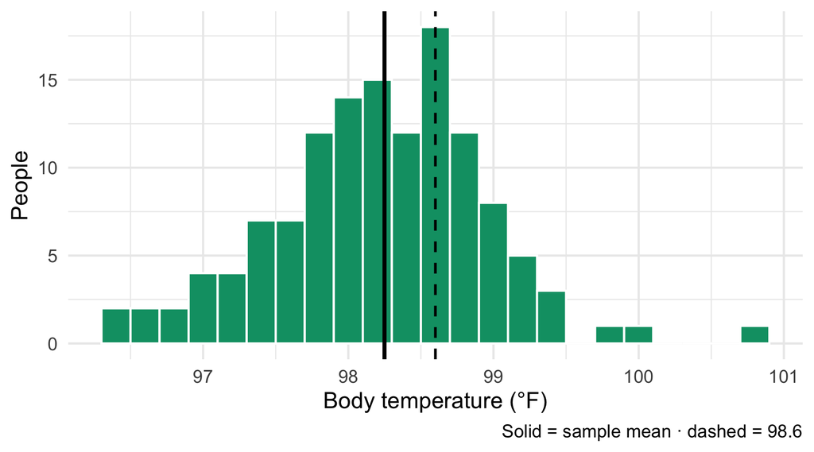

| n | Mean (°F) | SD (°F) |
| --- | --- | --- |
| 130 | 98.25 | 0.73 |

## Step 0

0 · Set α1 · Hypotheses2 · Test statistic3A · Null world3B · p-value4 · Conclusion

$\alpha = 0.05$

## Step 1

0 · Set α1 · Hypotheses2 · Test statistic3A · Null world3B · p-value4 · Conclusion

$H_0: \mu = 98.6$

$H_A: \mu < 98.6$

- $\mu$ = **true** mean body temperature
- **One-sided** ( < ): researchers suspected a **decrease** before collecting data

## Step 2

0 · Set α1 · Hypotheses2 · Test statistic3A · Null world3B · p-value4 · Conclusion

```r
obs_temp <- temp_data %>%
  specify(response = temp) %>%
  calculate(stat = "mean") %>%
  pull(stat)
```

$\bar{x} = \mathbf{98.25}$ °F

## Step 3A — shift

0 · Set α1 · Hypotheses2 · Test statistic3A · Null world3B · p-value4 · Conclusion

$H_0$ only gives the **center**. Borrow the shape and spread from our sample: **add 0.35 °F to everyone.**

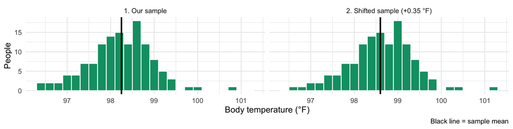

Same shape and spread, mean exactly 98.6 → that’s the null world

## Step 3A — bootstrap 1000 times

0 · Set α1 · Hypotheses2 · Test statistic3A · Null world3B · p-value4 · Conclusion

```r
null_temp <- temp_data %>%
  specify(response = temp) %>%
  hypothesize(null = "point",
              mu = 98.6) %>%
  generate(reps = 1000,
           type = "bootstrap") %>%
  calculate(stat = "mean")
```

`hypothesize(mu = 98.6)` **does the shift for you**.

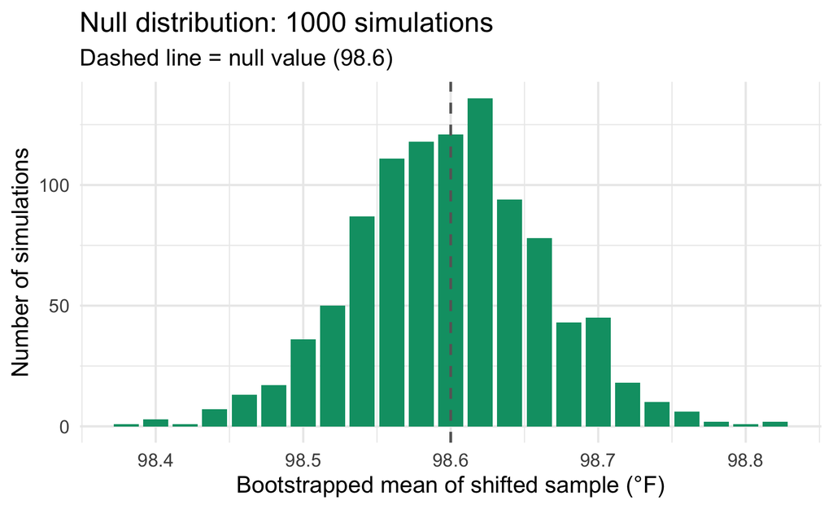

## Step 3B

0 · Set α1 · Hypotheses2 · Test statistic3A · Null world3B · p-value4 · Conclusion

$H_A$: $<$ → shade **left** (`direction = "less"`)

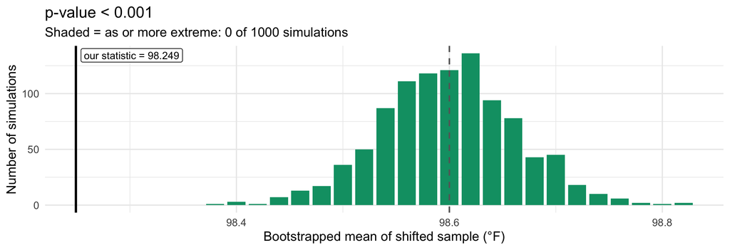

```r
null_temp %>% get_p_value(obs_stat = obs_temp, direction = "less")
```

## Step 4

0 · Set α1 · Hypotheses2 · Test statistic3A · Null world3B · p-value4 · Conclusion

p-value < 0.001 < α = 0.05

Reject H₀

There is **sufficient evidence** that the **true** mean body temperature is **less than 98.6 °F**.

$\triangle$ Write **p < 0.001**, not “p = 0”: none of 1000 simulations was that extreme.

# One median — Body temperature

## The data

Same 130 adults. This time: is the **median** different from 98.6 °F?

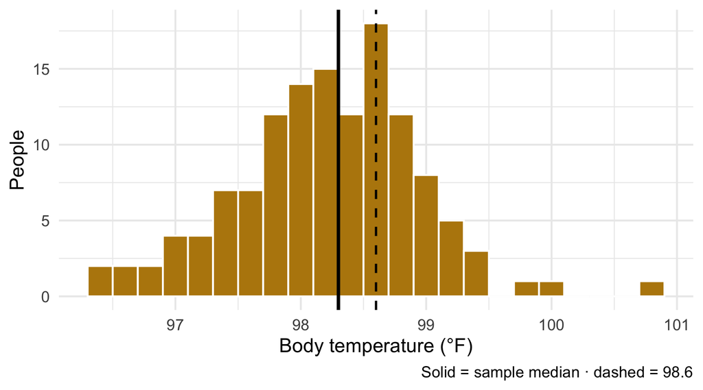

| n | Median (°F) |
| --- | --- |
| 130 | 98.3 |

## Step 0

0 · Set α1 · Hypotheses2 · Test statistic3A · Null world3B · p-value4 · Conclusion

$\alpha = 0.05$

## Step 1

0 · Set α1 · Hypotheses2 · Test statistic3A · Null world3B · p-value4 · Conclusion

$H_0$: median = 98.6

$H_A$: median $\ne$ 98.6

- The **true** median body temperature (write “median” in words)
- **Two-sided** ( $\ne$ ): “different from” counts in **either** direction

## Step 2

0 · Set α1 · Hypotheses2 · Test statistic3A · Null world3B · p-value4 · Conclusion

```r
obs_temp_med <- temp_data %>%
  specify(response = temp) %>%
  calculate(stat = "median") %>%
  pull(stat)
```

Sample median = **98.3** °F

## Step 3A

0 · Set α1 · Hypotheses2 · Test statistic3A · Null world3B · p-value4 · Conclusion

Same idea as the mean: **shift** every temperature up 0.3 °F so the median is 98.6, then **bootstrap medians**.

```r
null_temp_med <- temp_data %>%
  specify(response = temp) %>%
  hypothesize(null = "point",
              med = 98.6) %>%
  generate(reps = 1000,
           type = "bootstrap") %>%
  calculate(stat = "median")
```

`med = 98.6` **does the shift for you**.

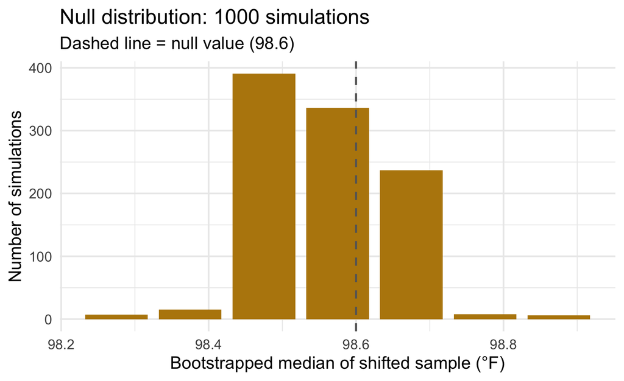

## Step 3B

0 · Set α1 · Hypotheses2 · Test statistic3A · Null world3B · p-value4 · Conclusion

$H_A$: $\ne$ → shade **both tails** (`direction = "two-sided"`)

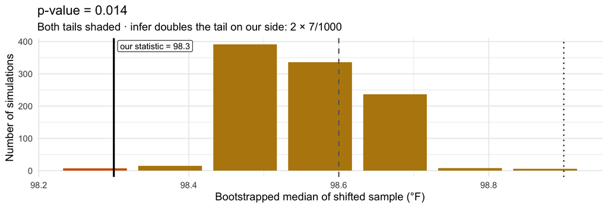

```r
null_temp_med %>% get_p_value(obs_stat = obs_temp_med, direction = "two-sided")
```

## Step 4

0 · Set α1 · Hypotheses2 · Test statistic3A · Null world3B · p-value4 · Conclusion

p-value = 0.014 < α = 0.05

Reject H₀

There is **sufficient evidence** that the **true** median body temperature is **different from 98.6 °F**.

# Wrap-up

## Summary of Single Parameter Tests

| Step | **One proportion** | **One mean** | **One median** |
| --- | --- | --- | --- |
| **0** α | 0.05 | 0.05 | 0.05 |
| **1** $H_A$ | $p \ne 0.25$ | $\mu < 98.6$ | median $\ne$ 98.6 |
| **2** `stat =` | `"prop"` | `"mean"` | `"median"` |
| **2** value | 0.4 | 98.25 | 98.3 |
| **3A** null | **draw** from $p_0$ | **shift** + bootstrap | **shift** + bootstrap |
| **3B** `direction =` | `"two-sided"` | `"less"` | `"two-sided"` |
| **3B** p-value | 0.140 | < 0.001 | 0.014 |
| **4** decision | Fail to reject | Reject | Reject |

## Two groups vs. one group

|  | Two groups (Part 2) | One group (Part 3) |
| --- | --- | --- |
| $H_0$ | difference = 0 | parameter = claimed value |
| `specify()` | `response` **and** `explanatory` | `response` only |
| `hypothesize()` | `null = "independence"` | `null = "point"` + `p`, `mu`, or `med` |
| `generate(type =` | `"permute"` | `"draw"` (proportion) or `"bootstrap"` (mean, median) |
| Null centered at | 0 | the claimed value |
| Steps 0, 3B, 4 | same | same |

## Conclusion templates

| Reject $H_0$ | Fail to reject $H_0$ |
| --- | --- |
| Our p-value of ___ is **less than** α = 0.05, so we **reject $H_0$**. There is **sufficient evidence** to say [$H_A$ in context]. | Our p-value of ___ is **greater than** α = 0.05, so we **fail to reject $H_0$**. There is **NOT enough evidence** to say [$H_A$ in context]. |

**Never** “accept $H_0$.”

# Appendix: building the null world

## The recipe

**1. Build a world** where $H_0$ is **true**, but that otherwise looks like our data

→

**2. Sample** from it the **same way** we got our data (same $n$)

→

**3. Compute** the **same statistic** as Step 2

→

**4. Repeat** 1000×

The only hard part is step 1: **how do we make $H_0$ true?**

It depends on what $H_0$ says.

## Three distributions you’ve seen

|  | Sampling distribution | Bootstrap distribution | **Null distribution** |
| --- | --- | --- | --- |
| **Lesson** | 18 | 19–21 | 22–25 |
| **Samples from** | The real population | Our sample (with replacement) | A world where **$H_0$ is true** |
| **Centered at** | The parameter | Our statistic | The **null value** |
| **Can we build it?** | Almost never | Yes | Yes |
| **Used for** | Theory | Confidence intervals | **Hypothesis tests (p-values)** |

Null distribution = **what chance alone would produce** if $H_0$ were true.

## Cheat sheet: common test statistics

| Test statistic | $H_0$ | How we make $H_0$ true | `hypothesize()` | `generate(type =` | Centered at |
| --- | --- | --- | --- | --- | --- |
| Difference in **proportions** | $p_1 - p_2 = 0$ | **Shuffle** group labels | `null = "independence"` | `"permute"` | 0 |
| Difference in **means** | $\mu_1 - \mu_2 = 0$ | **Shuffle** group labels | `null = "independence"` | `"permute"` | 0 |
| Difference in **medians** | median$_1$ − median$_2$ = 0 | **Shuffle** group labels | `null = "independence"` | `"permute"` | 0 |
| One **proportion** | $p = p_0$ | **Draw** from a world that is exactly $p_0$ | `null = "point", p = p0` | `"draw"` | $p_0$ |
| One **mean** | $\mu = \mu_0$ | **Shift** the sample to mean $\mu_0$, then bootstrap | `null = "point", mu = mu0` | `"bootstrap"` | $\mu_0$ |
| One **median** | median = $m_0$ | **Shift** the sample to median $m_0$, then bootstrap | `null = "point", med = m0` | `"bootstrap"` | $m_0$ |

**Two groups → shuffle.** **One group → draw (proportion) or shift + bootstrap (mean, median).**

## Two groups: why shuffling works

$H_0$: the group **doesn’t matter**. If that’s true, any patient’s result could just as easily have been in either group.

| Heart rate | Real label | Shuffle 1 | Shuffle 2 |
| --- | --- | --- | --- |
| 65 | female | male | female |
| 83 | female | female | female |
| 62 | female | female | female |
| 77 | female | male | male |
| 70 | male | male | male |
| 84 | male | female | male |
| 81 | male | male | female |
| 71 | male | female | male |
| **x̄ male − x̄ female** | **4.75** | **-1.75** | **2.75** |

**Stays the same**

- Every heart-rate value
- Group sizes (4 and 4)

**Changes**

- **Which** values land in **which** group

Each shuffle → one dot in the null distribution

## Bootstrap vs. null: same spread, different center

Body temperature again. One sample, two distributions:

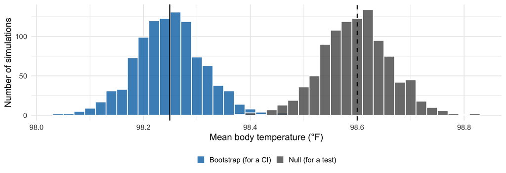

**Bootstrap** (no `hypothesize()`): centered at **our** $\bar{x}$ = 98.25 → where the truth might be

**Null** (`hypothesize(mu = 98.6)`): centered at the **claim** → what chance would do if $H_0$ were true

## Common mistakes

| $\triangle$ Mistake | Fix |
| --- | --- |
| Null distribution centered at **our statistic** | That’s a **bootstrap** distribution. The null is centered at the **null value**. |
| Two groups with `type = "bootstrap"` | Two groups → `"independence"` + `"permute"` |
| One proportion with `type = "permute"` | Nothing to shuffle → `"point"` + `"draw"` |
| Shuffling values **within** a group | Shuffle the **labels** across groups |
| `order =` doesn’t match $H_0$ | Same subtraction in $H_0$, `calculate()`, and the conclusion |
| Reporting “p = 0” | Write **p < 0.001** (with 1,000 reps) |